# 01_jupyter_basic

```python
#주피터 노트북 : 파이썬 쉘환경 + 코드 파일 작성을 동시에 수행하고 코드와 실행결과를 하나의 파일에 저장할 수 있는 웹 기반 개발환경
#파일 확장자 .ipynb

#코드를 작성할 수 있는 이 박스를 cell 이라고 부름.

print('Hello jupyter notebook')
```

```
Hello jupyter notebook
```

```python
name= 'sam'
print(name)
```

```
sam
```

```python
100
```

```
100
```

```python
50+30
```

```
80
```

```python
print('Hello')
```

```
Hello
```

```python
# cell 실행모드 3가지
print('Hello')
```

```
Hello
```

```python
#셀의 실행순서대로 코드가 실행됨. 작성된 순서가 아님

#[1] 변수 선언
num= 100
```

```python
#[2] 변수 연산
num += 50
```

```python
#[3] 연산결과 출력
print(num)
```

```
150
```

```python
#에러 발생위치 확인
name= 'robin'
print(name)
print(nice to meet you)
```

```
  Cell In[11], line 4
    print(nice to meet you)
          ^
SyntaxError: invalid syntax. Perhaps you forgot a comma?
```

```python
#모듈 사용하기
import random
num= random.randint(1,46)
print(num)
```

```
31
```

```python
num= random.randint? # ?를 사용하면 함수의 설명을 볼 수 있음. --실행
```

```
  Cell In[66], line 1
    num= random.randint? # ?를 사용하면 함수의 설명을 볼 수 있음. --실행
                       ^
SyntaxError: invalid syntax
```

```python
#[]안에 숫자가 있어야 실행완료.. 혹시 * 이면 실행중
import time
for i in range(10):
    print(i)
```

```
0
1
2
3
4
5
6
7
8
9
```

```python
#주피터 노트북의 장점 - 설명을 작성하기 위한 cell 을 만들 수 있음.
# 코드 cell 이 아닌 마크다운문법을 사용할 수 있는 설명 cell 을 사용해보기
```

마크다운 문법을 작성할 수 있어요. 실행은 코드처럼 ctrl+enter 로 실행하면 마크다운을 랜더링한 결과 화면이 보여짐.  
마크다운 문법이기에 엔터를 친다고 줄바꿈되지 않음. 줄바꿈 하려면 br태그같은 역할의 문법.  
띄어쓰기 2번.  
이렇게...

마크다운 언어의 제목요소 표시 h1~h6를 대체.. # 의 개수로 (띄어쓰기 있어야 함)

# 제목1

## 제목2

### 제목3

#### 제목4

##### 제목5

###### 제목6

####### 제목7은 없음.

**bold** 또는 **bold** 를 통해 strong(강하게) 표시 가능  
*itallic* 또는 *italic* 를 통해 emphasize(강조) 표시 가능  
**bold and italic** 또는 **bold and italic** 를 통해 bold+italic 표시 가능

> 인용구를 만들 수도 있음.  
> 인용구도 공백문자 2개가 있어야 줄바꿈 됨.  
> 이렇게

### unordered list

- 리스트1
- 리스트2
- 리스트3

### ordered list

1. aaa
2. bbb
3. ccc

순서가 있는 리스트는 모두 1을 써도 자동 증가됨

1. aaa
2. bbb
3. ccc

## 이미지 표시

- windows 에서 print screen 으로 이미지 캡쳐하여 붙여넣기 하면 이미지가 표시됨

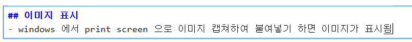

- 특정 이미지의 경로를 직접 지정(스타일지정 {}는 GitHub에서는 인식되고..노트북에서는 안됨)

[figure not shown]

  {: width="100" height="100"}
- 크기 지정을 하려면 마크업언어 사용

## 마크다운 링크 요소

[네이버](https://www.naver.com)

## 유튜브 영상 링크

유튜브 동영상의 마우스 우클릭하여 **소스코드 복사** 를 누르고 cell에 붙여넣기

[video not shown]

iframe 의 사용은 코드 cell 에서 %%html 을 입력한 다음 붙여넣기해야 함.

```python
%%html
<iframe width="480" height="280" src="https://www.youtube.com/embed/UkFLk0-xf58" title="[MV] 헌트릭스(HUNTR/X) - Golden l 한글자막 뮤직비디오" frameborder="0" allow="accelerometer; autoplay; clipboard-write; encrypted-media; gyroscope; picture-in-picture; web-share" referrerpolicy="strict-origin-when-cross-origin" allowfullscreen></iframe>
```

[video not shown]

```python
# 노트북 파일 .ipynb 파일을 다른 형태로 변환하여 추출 및 다운로드 가능.

#1. html 파일로 다운로드 ( 파이썬 개발환경이 없는 곳에서 코드와 실행결과 확인가능)
#2. pdf 파일로 다운로드  ( 파이썬 개발환경이 없는 곳에서 코드와 실행결과 확인가능)
#3. .py 파일로 다운로드  ( 코드가 아닌 cell들은 모두 주석처리됨 )
```